# Rapport_partie_1

Tristan Plasse & Yohan Wegener

2026-04-07

# Partie 1 : Recréation des résultats d’une expérience

Dans le cadre de ce projet, nous allons recréer les analyses de Bannester-Marchand et al. (2025)

## Question biologique

Quelle est la situation du Chevalier cuivré (*Moxostoma hubbsi*) en considérant sa probabilité d’extinction, sa tendance démographique et l’effet de l’ensemencement ?

## Hypothèse

La situation du Chevalier cuivré étant précaire, nous supposons que la population présente une probabilité d’extinction élevée, une tendance démographique à la baisse et nécessiterait un ensemencement élevé pour obtenir le maintien de sa population.

## Données et/ou informations pertinentes

Les matrices de Leslie ont été tirées de Bannester-Marchand et al. (2025), et les étapes pour les atteindre sont détaillées dans les sections 2.1 et 2.2 de l’article.

##### Matrice mesurée

```r
# Creation du nom de chaque stade
noms_stades <- c("Oeufs", "Larve", "Alevins", paste0("Age", 1:30))
# Nombre de stades
n_stades <- length(noms_stades)

# Créer une matrice vide (remplie de 0)
measured <- matrix(0, nrow = n_stades, ncol = n_stades,
                   dimnames = list(noms_stades, noms_stades))
# Remplir la première ligne (Fécondité)
fecondite_m <- c(18096, 21035, 24114, 27133, 29563, 31934, 34142, 35761,
               37062, 38435, 39821, 40936, 41923, 42972, 44075, 45086,
               46025, 46914, 47767, 48568)

# On place ces valeurs de Age 11 à Age 30 (colonnes 14 à 33)
# Avant = pas à maturité sexuelle
measured[1, 13:32] <- fecondite_m

# Remplir la sous-diagonale (Taux de survie)
survie_m <- c(
  0.073, 0.023, 0.006, 0.609, 0.723, 0.778, 0.812, 0.836, 0.851, 0.863, 0.875, 0.887, 0.893, # Jusqu'à Age 10
  0.895, 0.898, 0.902, 0.903, 0.905, 0.908, 0.910, 0.910, 0.910, 0.911, 0.912, 0.911, 0.911, # Jusqu'à Age 22
  0.912, 0.912, 0.912, 0.913, 0.913, 0.913 # Fin
)

# On injecte ces valeurs dans la sous-diagonale (ligne i+1, colonne i)
for(i in 1:length(survie_m)) {
  measured[i+1, i] <- survie_m[i]
}

# Affichage du lambda
res_lambda <- data.frame(
  Scenario = c("Mesuré", "Étude"),
  Lambda = c(max(Re(eigen(measured)$values)), 0.957)
)
res_lambda %>%
  kable(caption = "Comparaison du taux de croissance (Lambda)", align = "c") %>%
  kable_styling(
    bootstrap_options = c("striped", "hover", "condensed"),
    full_width = FALSE,  # Empêche l'étirement
    position = "center"
  )
```

Comparaison du taux de croissance (Lambda)

| Scenario | Lambda |
| --- | --- |
| Mesuré | 0.9567296 |
| Étude | 0.9570000 |

```r
# Affichage interactif de la matrice de Leslie
datatable(round(measured, 4),
          class = 'cell-border stripe compact',
          options = list(scrollX = TRUE, pageLength = 10))
```

|  | Oeufs | Larve | Alevins | Age1 | Age2 | Age3 | Age4 | Age5 | Age6 | Age7 | Age8 | Age9 | Age10 | Age11 | Age12 | Age13 | Age14 | Age15 | Age16 | Age17 | Age18 | Age19 | Age20 | Age21 | Age22 | Age23 | Age24 | Age25 | Age26 | … |
| --- | --- | --- | --- | --- | --- | --- | --- | --- | --- | --- | --- | --- | --- | --- | --- | --- | --- | --- | --- | --- | --- | --- | --- | --- | --- | --- | --- | --- | --- | --- |
| Oeufs | 0 | 0 | 0 | 0 | 0 | 0 | 0 | 0 | 0 | 0 | 0 | 0 | 18096 | 21035 | 24114 | 27133 | 29563 | 31934 | 34142 | 35761 | 37062 | 38435 | 39821 | 40936 | 41923 | 42972 | 44075 | 45086 | 46025 | … |
| Larve | 0.073 | 0 | 0 | 0 | 0 | 0 | 0 | 0 | 0 | 0 | 0 | 0 | 0 | 0 | 0 | 0 | 0 | 0 | 0 | 0 | 0 | 0 | 0 | 0 | 0 | 0 | 0 | 0 | 0 | … |
| Alevins | 0 | 0.023 | 0 | 0 | 0 | 0 | 0 | 0 | 0 | 0 | 0 | 0 | 0 | 0 | 0 | 0 | 0 | 0 | 0 | 0 | 0 | 0 | 0 | 0 | 0 | 0 | 0 | 0 | 0 | … |
| Age1 | 0 | 0 | 0.006 | 0 | 0 | 0 | 0 | 0 | 0 | 0 | 0 | 0 | 0 | 0 | 0 | 0 | 0 | 0 | 0 | 0 | 0 | 0 | 0 | 0 | 0 | 0 | 0 | 0 | 0 | … |
| Age2 | 0 | 0 | 0 | 0.609 | 0 | 0 | 0 | 0 | 0 | 0 | 0 | 0 | 0 | 0 | 0 | 0 | 0 | 0 | 0 | 0 | 0 | 0 | 0 | 0 | 0 | 0 | 0 | 0 | 0 | … |
| Age3 | 0 | 0 | 0 | 0 | 0.723 | 0 | 0 | 0 | 0 | 0 | 0 | 0 | 0 | 0 | 0 | 0 | 0 | 0 | 0 | 0 | 0 | 0 | 0 | 0 | 0 | 0 | 0 | 0 | 0 | … |
| Age4 | 0 | 0 | 0 | 0 | 0 | 0.778 | 0 | 0 | 0 | 0 | 0 | 0 | 0 | 0 | 0 | 0 | 0 | 0 | 0 | 0 | 0 | 0 | 0 | 0 | 0 | 0 | 0 | 0 | 0 | … |
| Age5 | 0 | 0 | 0 | 0 | 0 | 0 | 0.812 | 0 | 0 | 0 | 0 | 0 | 0 | 0 | 0 | 0 | 0 | 0 | 0 | 0 | 0 | 0 | 0 | 0 | 0 | 0 | 0 | 0 | 0 | … |
| Age6 | 0 | 0 | 0 | 0 | 0 | 0 | 0 | 0.836 | 0 | 0 | 0 | 0 | 0 | 0 | 0 | 0 | 0 | 0 | 0 | 0 | 0 | 0 | 0 | 0 | 0 | 0 | 0 | 0 | 0 | … |
| Age7 | 0 | 0 | 0 | 0 | 0 | 0 | 0 | 0 | 0.851 | 0 | 0 | 0 | 0 | 0 | 0 | 0 | 0 | 0 | 0 | 0 | 0 | 0 | 0 | 0 | 0 | 0 | 0 | 0 | 0 | … |

[output cut: 23 more lines]

##### Matrice menacée

```r
# Créer une matrice vide (remplie de 0)
endangered <- matrix(0, nrow = n_stades, ncol = n_stades,
                     dimnames = list(noms_stades, noms_stades))

# Remplir la première ligne (Fécondité)
fecondite_e <- c(18523, 21571, 24749, 27847, 30339, 32771, 35037, 36699,
               38034, 39442, 40865, 42009, 43022, 44098, 45230, 46268,
               47231, 48144, 49019, 49841)

# On place ces valeurs de Age 11 à Age 30 (colonnes 14 à 33)
endangered[1, 13:32] <- fecondite_e

# Remplir la sous-diagonale (Taux de survie)
survie_e <- c(
  0.075, 0.023, 0.007, 0.625, 0.741, 0.798, 0.833, 0.857, 0.873, 0.885, 0.898, 0.910, 0.916, # Jusqu'à Age 10
  0.918, 0.921, 0.926, 0.927, 0.929, 0.932, 0.933, 0.933, 0.934, 0.935, 0.935, 0.935, 0.935, # Suite
  0.936, 0.936, 0.936, 0.937, 0.937, 0.937 # Fin
)

# On injecte ces valeurs dans la sous-diagonale (ligne i+1, colonne i)
for(i in 1:length(survie_e)) {
  endangered[i+1, i] <- survie_e[i]
}

# Affichage du lambda
res_lambda <- data.frame(
  Scenario = c("Menacée", "Étude"),
  Lambda = c(max(Re(eigen(endangered)$values)), 0.984)
)
res_lambda %>%
  kable(caption = "Comparaison du taux de croissance (Lambda)", align = "c") %>%
  kable_styling(
    bootstrap_options = c("striped", "hover", "condensed"),
    full_width = FALSE,  # Empêche l'étirement
    position = "center"
  )
```

Comparaison du taux de croissance (Lambda)

| Scenario | Lambda |
| --- | --- |
| Menacée | 0.9861269 |
| Étude | 0.9840000 |

```r
# Affichage interactif de la matrice de Leslie
datatable(round(endangered, 4),
          class = 'cell-border stripe compact',
          options = list(scrollX = TRUE, pageLength = 10))
```

|  | Oeufs | Larve | Alevins | Age1 | Age2 | Age3 | Age4 | Age5 | Age6 | Age7 | Age8 | Age9 | Age10 | Age11 | Age12 | Age13 | Age14 | Age15 | Age16 | Age17 | Age18 | Age19 | Age20 | Age21 | Age22 | Age23 | Age24 | Age25 | Age26 | … |
| --- | --- | --- | --- | --- | --- | --- | --- | --- | --- | --- | --- | --- | --- | --- | --- | --- | --- | --- | --- | --- | --- | --- | --- | --- | --- | --- | --- | --- | --- | --- |
| Oeufs | 0 | 0 | 0 | 0 | 0 | 0 | 0 | 0 | 0 | 0 | 0 | 0 | 18523 | 21571 | 24749 | 27847 | 30339 | 32771 | 35037 | 36699 | 38034 | 39442 | 40865 | 42009 | 43022 | 44098 | 45230 | 46268 | 47231 | … |
| Larve | 0.075 | 0 | 0 | 0 | 0 | 0 | 0 | 0 | 0 | 0 | 0 | 0 | 0 | 0 | 0 | 0 | 0 | 0 | 0 | 0 | 0 | 0 | 0 | 0 | 0 | 0 | 0 | 0 | 0 | … |
| Alevins | 0 | 0.023 | 0 | 0 | 0 | 0 | 0 | 0 | 0 | 0 | 0 | 0 | 0 | 0 | 0 | 0 | 0 | 0 | 0 | 0 | 0 | 0 | 0 | 0 | 0 | 0 | 0 | 0 | 0 | … |
| Age1 | 0 | 0 | 0.007 | 0 | 0 | 0 | 0 | 0 | 0 | 0 | 0 | 0 | 0 | 0 | 0 | 0 | 0 | 0 | 0 | 0 | 0 | 0 | 0 | 0 | 0 | 0 | 0 | 0 | 0 | … |
| Age2 | 0 | 0 | 0 | 0.625 | 0 | 0 | 0 | 0 | 0 | 0 | 0 | 0 | 0 | 0 | 0 | 0 | 0 | 0 | 0 | 0 | 0 | 0 | 0 | 0 | 0 | 0 | 0 | 0 | 0 | … |
| Age3 | 0 | 0 | 0 | 0 | 0.741 | 0 | 0 | 0 | 0 | 0 | 0 | 0 | 0 | 0 | 0 | 0 | 0 | 0 | 0 | 0 | 0 | 0 | 0 | 0 | 0 | 0 | 0 | 0 | 0 | … |
| Age4 | 0 | 0 | 0 | 0 | 0 | 0.798 | 0 | 0 | 0 | 0 | 0 | 0 | 0 | 0 | 0 | 0 | 0 | 0 | 0 | 0 | 0 | 0 | 0 | 0 | 0 | 0 | 0 | 0 | 0 | … |
| Age5 | 0 | 0 | 0 | 0 | 0 | 0 | 0.833 | 0 | 0 | 0 | 0 | 0 | 0 | 0 | 0 | 0 | 0 | 0 | 0 | 0 | 0 | 0 | 0 | 0 | 0 | 0 | 0 | 0 | 0 | … |
| Age6 | 0 | 0 | 0 | 0 | 0 | 0 | 0 | 0.857 | 0 | 0 | 0 | 0 | 0 | 0 | 0 | 0 | 0 | 0 | 0 | 0 | 0 | 0 | 0 | 0 | 0 | 0 | 0 | 0 | 0 | … |
| Age7 | 0 | 0 | 0 | 0 | 0 | 0 | 0 | 0 | 0.873 | 0 | 0 | 0 | 0 | 0 | 0 | 0 | 0 | 0 | 0 | 0 | 0 | 0 | 0 | 0 | 0 | 0 | 0 | 0 | 0 | … |

[output cut: 23 more lines]

##### Matrice nulle

```r
# Créer une matrice vide (remplie de 0)
null_pred <- matrix(0, nrow = n_stades, ncol = n_stades,
                    dimnames = list(noms_stades, noms_stades))

# Remplissage de la Fécondité (Ligne 1)
fecondite_n <- c(
  18822, 21920, 25150, 28298, 30830, 33301, 35604, 37292, 38649, 40080,
  41526, 42689, 43718, 44811, 45962, 47017, 47996, 48923, 49813, 50648
)

# On les place de la colonne 13 (Age 10) à la colonne 32 (Age 29)
null_pred[1, 13:32] <- fecondite_n

# Remplissage de la Survie (Sous-diagonale)
survie_n <- c(
  0.076, 0.024, 0.007, 0.635, 0.753, 0.811, 0.847, 0.871, 0.888, 0.899, 0.912, 0.924, 0.931,
  0.933, 0.936, 0.941, 0.942, 0.944, 0.947, 0.949, 0.949, 0.949, 0.950, 0.951, 0.950, 0.950,
  0.951, 0.951, 0.951, 0.952, 0.952, 0.952
)
# On injecte ces valeurs dans la sous-diagonale (ligne i+1, colonne i)
for(i in 1:length(survie_n)) {
  null_pred[i+1, i] <- survie_n[i]
}

# Affichage du lambda
res_lambda <- data.frame(
  Scenario = c("Nulle", "Étude"),
  Lambda = c(max(Re(eigen(null_pred)$values)), 1)
)
res_lambda %>%
  kable(caption = "Comparaison du taux de croissance (Lambda)", align = "c") %>%
  kable_styling(
    bootstrap_options = c("striped", "hover", "condensed"),
    full_width = FALSE,  # Empêche l'étirement
    position = "center"
  )
```

Comparaison du taux de croissance (Lambda)

| Scenario | Lambda |
| --- | --- |
| Nulle | 1.002494 |
| Étude | 1.000000 |

```r
# Affichage interactif de la matrice de Leslie
datatable(round(null_pred, 4),
          class = 'cell-border stripe compact',
          options = list(scrollX = TRUE, pageLength = 10))
```

|  | Oeufs | Larve | Alevins | Age1 | Age2 | Age3 | Age4 | Age5 | Age6 | Age7 | Age8 | Age9 | Age10 | Age11 | Age12 | Age13 | Age14 | Age15 | Age16 | Age17 | Age18 | Age19 | Age20 | Age21 | Age22 | Age23 | Age24 | Age25 | Age26 | … |
| --- | --- | --- | --- | --- | --- | --- | --- | --- | --- | --- | --- | --- | --- | --- | --- | --- | --- | --- | --- | --- | --- | --- | --- | --- | --- | --- | --- | --- | --- | --- |
| Oeufs | 0 | 0 | 0 | 0 | 0 | 0 | 0 | 0 | 0 | 0 | 0 | 0 | 18822 | 21920 | 25150 | 28298 | 30830 | 33301 | 35604 | 37292 | 38649 | 40080 | 41526 | 42689 | 43718 | 44811 | 45962 | 47017 | 47996 | … |
| Larve | 0.076 | 0 | 0 | 0 | 0 | 0 | 0 | 0 | 0 | 0 | 0 | 0 | 0 | 0 | 0 | 0 | 0 | 0 | 0 | 0 | 0 | 0 | 0 | 0 | 0 | 0 | 0 | 0 | 0 | … |
| Alevins | 0 | 0.024 | 0 | 0 | 0 | 0 | 0 | 0 | 0 | 0 | 0 | 0 | 0 | 0 | 0 | 0 | 0 | 0 | 0 | 0 | 0 | 0 | 0 | 0 | 0 | 0 | 0 | 0 | 0 | … |
| Age1 | 0 | 0 | 0.007 | 0 | 0 | 0 | 0 | 0 | 0 | 0 | 0 | 0 | 0 | 0 | 0 | 0 | 0 | 0 | 0 | 0 | 0 | 0 | 0 | 0 | 0 | 0 | 0 | 0 | 0 | … |
| Age2 | 0 | 0 | 0 | 0.635 | 0 | 0 | 0 | 0 | 0 | 0 | 0 | 0 | 0 | 0 | 0 | 0 | 0 | 0 | 0 | 0 | 0 | 0 | 0 | 0 | 0 | 0 | 0 | 0 | 0 | … |
| Age3 | 0 | 0 | 0 | 0 | 0.753 | 0 | 0 | 0 | 0 | 0 | 0 | 0 | 0 | 0 | 0 | 0 | 0 | 0 | 0 | 0 | 0 | 0 | 0 | 0 | 0 | 0 | 0 | 0 | 0 | … |
| Age4 | 0 | 0 | 0 | 0 | 0 | 0.811 | 0 | 0 | 0 | 0 | 0 | 0 | 0 | 0 | 0 | 0 | 0 | 0 | 0 | 0 | 0 | 0 | 0 | 0 | 0 | 0 | 0 | 0 | 0 | … |
| Age5 | 0 | 0 | 0 | 0 | 0 | 0 | 0.847 | 0 | 0 | 0 | 0 | 0 | 0 | 0 | 0 | 0 | 0 | 0 | 0 | 0 | 0 | 0 | 0 | 0 | 0 | 0 | 0 | 0 | 0 | … |
| Age6 | 0 | 0 | 0 | 0 | 0 | 0 | 0 | 0.871 | 0 | 0 | 0 | 0 | 0 | 0 | 0 | 0 | 0 | 0 | 0 | 0 | 0 | 0 | 0 | 0 | 0 | 0 | 0 | 0 | 0 | … |
| Age7 | 0 | 0 | 0 | 0 | 0 | 0 | 0 | 0 | 0.888 | 0 | 0 | 0 | 0 | 0 | 0 | 0 | 0 | 0 | 0 | 0 | 0 | 0 | 0 | 0 | 0 | 0 | 0 | 0 | 0 | … |

[output cut: 23 more lines]

```r
Ensemencement_nul      <- c(0, 0)# larves, alevins
Ensemencement_present  <- c(231185, 14868)
Ensemencement_propose  <- c(500000, 15000)
```

## Méthode

Un modèle de viabilité des populations avec stochasticité annuelle des taux de survie et de fécondité a été développé.

Les modèles stochastiques ont été simulés avec $N = 5000$ itérations sur une période de $t = 100$ ans. La probabilité d’extinction est définie par la condition où l’abondance totale devient nulle :

$$P_{ext} = P(\exists t \in [0, 100] :
n_{total}(t) = 0)$$

De plus, nous avons calculé la probabilité que l’abondance des individus matures $n_{mat}$ se maintienne au-dessus de seuils critiques $k$ pour favoriser la diversité génétique :

$$P(n_{mat}(t) > k), \quad \forall t
\in [0, 100] \text{ où } k \in \{0, 1000\}$$
Pour la survie de chaque âge, la stochasticité a été calculée à l’aide de :

$$s_{age}(t) \sim \text{Beta} (\alpha,
\beta)$$

$$\alpha = \frac{s_{age} \times \beta}{1 -
s_{age}}$$

Où :

$s_{age}(t) =$ La survie de cette classe d’âge selon l’année (stochastique)

$s_{age} =$ La survie théorique de cette classe d’âge

$$\beta =
\begin{cases}
5.05 & \text{pour le stade 1 (œufs)} \\
20 & \text{pour le stade 2 (larves)} \\
75 & \text{pour le stade 3 (alevins)} \\
0.75 & \text{pour les stades adultes}
\end{cases}$$

Pour la fécondité à chaque âge, la stochasticité a été calculée à l’aide de :

$$f_{age} \sim N(\mu,\sigma^2)$$
La population initiale a été calculée à l’aide de :

$$n_{age+1,t+1} = n_{age,t} \times
s_{age}$$

Où :

$n_{age} =$ Nombre d’individus de cette classe d’âge particulière

$s_{age} =$ La survie théorique de cette classe d’âge

## Calcul

### Structure initiale

Fonction qui détermine le nombre initial de poissons à chaque stade selon le nombre de poissons matures initial.

```r
calculer_structure_initiale <- function(matrice_choisie, n_mature_cible) {
  n_stades <- nrow(matrice_choisie)
  p_mesure <- diag(matrice_choisie[-1, -ncol(matrice_choisie)])

  pop <- numeric(n_stades)

  # Partir de 1 individu au stade le plus vieux (stade 33)
  # et remonter en divisant par la survie
  pop[33] <- 1
  for (s in 32:4) {
    pop[s] <- pop[s + 1] / p_mesure[s]
  }

  # Stades jeunes (1-3) proportionnels
  pop[3] <- pop[4] / p_mesure[3]
  pop[2] <- pop[3] / p_mesure[2]
  pop[1] <- pop[2] / p_mesure[1]

  # Normaliser pour avoir n_mature_cible matures (stades 13-33)
  facteur <- n_mature_cible / sum(pop[13:33])

  return(round(pop * facteur)) #On arrondi pour être éviter des individus décimaux
}
```

### Stochasticité

Fonctions servant à créer une matrice de X années avec les valeurs de survie et fécondité stochastiques. Chaque ligne correspond à une année distincte et chaque colonne correspond au stade associé.

```r
fecondite_stochastique <- function(matrice, n_annees){
  # 1. Identifier le nombre de stades (33)
  n_stades <- nrow(matrice)

  # 2. Extraire la ligne de fécondité théorique (la ligne 1)
  f_theo <- matrice[1, ]

  # 3. Générer les multiplicateurs stochastiques
  # On crée une matrice de multiplicateurs centrés sur 1 (1 + bruit normal)
  multiplicateurs <- matrix(1 + rnorm(n_stades * n_annees, mean = 0, sd = 0.25),
                            nrow = n_stades,
                            ncol = n_annees)

  # 4. Appliquer ces multiplicateurs à nos fécondités théoriques
  taux_fec <- multiplicateurs * f_theo

  return(taux_fec)
}


survie_stochastique <- function(matrice, n_annees) {
    #  Préparer beta
  # (3 spécifiques + 29 répétitions de 0.75 = 32)
  b_params <- c(5.05, 20, 75, rep(0.75, 29))
  # Extraire la survie réelle (sous-diagonale)
  # Pour les matrices 33x33, p_mesure aura une longueur de 32
  p_mesure <- diag(matrice[-1, -ncol(matrice)])

  # Calcul de Alpha
  alpha_params <- (p_mesure * b_params) / (1 - p_mesure)

  # Génération de la matrice de tirages
  taux_survie <- matrix(rbeta(n = length(p_mesure) * n_annees,
                              shape1 = alpha_params,
                              shape2 = b_params),
                        nrow = length(p_mesure),
                        ncol = n_annees)

  return(taux_survie)
}
```

### Simulation

Fonction servant à faire 5000 itérations pendant 100 ans

```r
run_pva_simulation <- function(matrice, n_iterations, n_annees, n_ini, Ensemencement) {
  n_stades <- nrow(matrice)
  pop_init <- calculer_structure_initiale(matrice, n_ini)

  # Matrice de résultats : [Année, Itération]
  res_matures <- matrix(0, nrow = n_annees + 1, ncol = n_iterations)

  # Indices utiles
  idx_matures <- 13:33
  idx_adultes_source <- 4:32 # Stades à t
  idx_adultes_cible  <- 5:33 # Stades à t+1

  for (i in 1:n_iterations) {
    # Matrice de survie et fecondité stochastique
    mat_fec_stoch  <- fecondite_stochastique(matrice, n_annees)
    mat_surv_stoch <- survie_stochastique(matrice, n_annees)

    # 2. Initialisation de la population
    pop <- pop_init
    res_matures[1, i] <- sum(pop[idx_matures])

    # 3. Boucle temporelle (Projection)
    for (t in 1:n_annees) {
      pop_next <- numeric(n_stades)

      # --- ÉTAPE A : Survie des adultes (Age 1 -> Age 30) ---
      pop_next[idx_adultes_cible] <- round(pop[idx_adultes_source] * mat_surv_stoch[idx_adultes_source, t])

      # --- ÉTAPE B : Reproduction et recrutement ---
      # Ponte (Fécondité stochastique)
      n_oeufs <- round(sum(pop[idx_matures] * mat_fec_stoch[idx_matures, t]))

      # Survie des jeunes (Oeufs -> Larve -> Alevins) + Ensemencement
      # mat_surv_stoch[1,t] = survie Oeufs
      # mat_surv_stoch[2,t] = survie Larve
      # mat_surv_stoch[3,t] = survie Alevins

      n_larves <- round(n_oeufs * mat_surv_stoch[1, t]) + Ensemencement[1]
      n_alevins    <- round(n_larves * mat_surv_stoch[2, t]) + Ensemencement[2]

      # Recrutement final au stade 4 (Age 1)
      pop_next[4] <- round(n_alevins * mat_surv_stoch[3, t])

      # Mise à jour
      pop <- pop_next
      res_matures[t+1, i] <- sum(pop[idx_matures])
    }
  }

  return(res_matures)
}
```

### Figure 2

Fonction servant à faire 5000 itérations avec chaque matrice et chaque niveau d’ensemencement afin de déterminé la progression dans le temps (jusqu’à 100 ans) du nombre d’individus matures.

```r
# Paramètres globaux
N_SIM <- 5000
TEMPS <- 100
N_INI <- 2000

sim_nul_nul_2 <- run_pva_simulation(null_pred, N_SIM, TEMPS, N_INI, Ensemencement_nul)
sim_nul_pre_2  <- run_pva_simulation(null_pred, N_SIM, TEMPS, N_INI, Ensemencement_present)
sim_nul_pro_2 <- run_pva_simulation(null_pred, N_SIM, TEMPS, N_INI, Ensemencement_propose)

sim_end_nul_2 <- run_pva_simulation(endangered, N_SIM, TEMPS, N_INI, Ensemencement_nul)
sim_end_pre_2  <- run_pva_simulation(endangered, N_SIM, TEMPS, N_INI, Ensemencement_present)
sim_end_pro_2 <- run_pva_simulation(endangered, N_SIM, TEMPS, N_INI, Ensemencement_propose)

sim_mea_nul_2 <- run_pva_simulation(measured, N_SIM, TEMPS, N_INI, Ensemencement_nul)
sim_mea_pre_2  <- run_pva_simulation(measured, N_SIM, TEMPS, N_INI, Ensemencement_present)
sim_mea_pro_2 <- run_pva_simulation(measured, N_SIM, TEMPS, N_INI, Ensemencement_propose)
```

```r
format_sim_data <- function(mat_res, nom_scen) {
  data.frame(
    Annee = 0:TEMPS,
    Mediane = apply(mat_res, 1, median),
    Inf_95 = apply(mat_res, 1, quantile, 0.025),
    Sup_95 = apply(mat_res, 1, quantile, 0.975),
    Scenario = nom_scen
  )
}

df_nul <- bind_rows(
  format_sim_data(sim_nul_nul_2, "Sans ensemencement"),
  format_sim_data(sim_nul_pro_2, "Ensemencement théorique"),
  format_sim_data(sim_nul_pre_2, "Ensemencement actuel")
) %>% mutate(across(Mediane:Sup_95, ~pmax(.x, 0.0001)))

df_end <- bind_rows(
  format_sim_data(sim_end_nul_2, "Sans ensemencement"),
  format_sim_data(sim_end_pro_2, "Ensemencement théorique"),
  format_sim_data(sim_end_pre_2, "Ensemencement actuel")
) %>% mutate(across(Mediane:Sup_95, ~pmax(.x, 0.0001)))

df_mea <- bind_rows(
  format_sim_data(sim_mea_nul_2, "Sans ensemencement"),
  format_sim_data(sim_mea_pro_2, "Ensemencement théorique"),
  format_sim_data(sim_mea_pre_2, "Ensemencement actuel")
) %>% mutate(across(Mediane:Sup_95, ~pmax(.x, 0.0001)))
```

### Figure 3

Fonction servant à faire 5000 itérations pour les 3 matrices avec un niveau d’ensemencement spécifique en calculant le pourcentage de chance que la population soit sous un seuil spécifique après 100 ans

```r
# Paramètre modifié (entre fig. 2 et 3)
N_INI <- 1000

sim_nul_nul_3 <- run_pva_simulation(null_pred, N_SIM, TEMPS, N_INI, Ensemencement_nul)
sim_end_nul_3 <- run_pva_simulation(endangered, N_SIM, TEMPS, N_INI, Ensemencement_nul)
sim_mea_nul_3 <- run_pva_simulation(measured, N_SIM, TEMPS, N_INI, Ensemencement_nul)
```

```r
# Simulation pour la Figure 3 (Seuils)
# On utilise directement les résultats de la simulation faite pour Fig 2
calcul_seuil <- function(mat_res, nom_scen) {
  seuils <- seq(0, 1000, by = 5)
  # Proportion du temps passé sous le seuil (excluant l'année 0)
  frequences <- sapply(seuils, function(s) colMeans(mat_res[2:101, ] < s))

  data.frame(
    Threshold = seuils,
    Median = apply(frequences, 2, median),
    Inf_70 = apply(frequences, 2, quantile, 0.15),
    Sup_70 = apply(frequences, 2, quantile, 0.85),
    Scenario = nom_scen
  )
}

df_fig3 <- bind_rows(
  calcul_seuil(sim_nul_nul_3, "Null"),
  calcul_seuil(sim_end_nul_3, "Endangered"),
  calcul_seuil(sim_mea_nul_3, "Measured")
)

# Lissage des résultats
df_fig3$Scenario <- factor(df_fig3$Scenario, levels = c("Measured", "Endangered", "Null"))

df_smoothed <- df_fig3 %>%
  group_by(Scenario) %>%
  mutate(
    Median = predict(loess(Median ~ Threshold, span = 0.15)),
    Inf_70 = predict(loess(Inf_70 ~ Threshold, span = 0.15)),
    Sup_70 = predict(loess(Sup_70 ~ Threshold, span = 0.15)),

    # Empêche les valeurs négatives dues au lissage
    Median = pmax(Median, 0),
    Inf_70 = pmax(Inf_70, 0),
    Sup_70 = pmax(Sup_70, 0)
  ) %>%
  ungroup()
```

### Figure 4

Fonction utlisant le modèle déterministe afin de savoir combien d’individus mature il y aura dans 100 ans selon un ensemencement additionnel (en plus de l’ensemencement présentement utilisé) dans le scénario mesuré.

```r
fig_4 <- function(matrice_choisie, n_iterations = 100) {

  # 1. Paramètres fixes (ensemencement actuel)
  n_larve_base <- Ensemencement_present[1]
  n_alevins_base   <- Ensemencement_present[2]
  n_stades     <- nrow(matrice_choisie)
  # 2. Extraction de la survie
  s_stades     <- diag(matrice_choisie[-1, -n_stades])

  # Calcul des survies cumulées vers le stade 4 (Age 1)
  s_larve_to_4 <- s_stades[2] * s_stades[3] # Survie Larve -> Alevins -> Age 1
  s_alevins_to_4   <- s_stades[3] # Survie Alevins -> Age 1

  # 3. Sous-fonction pour calculer l'abondance finale pour un scénario précis
  simulate_point <- function(stocking_val, stage_to_stock) {

    # Initialisation de la population avec une structure stable (1000 matures)
    pop <- calculer_structure_initiale(matrice_choisie, 1000)

    # Projection sur 100 ans (cette figure utilise le modèle déterministe)
    for (t in 1:100) {
      # Multiplication matricielle : pop(t+1) = M * pop(t)
      pop <- as.vector(matrice_choisie %*% pop)

      # On applique l'ensemencement actuel (larves et alevins) à tous les scénarios
      pop[4] <- pop[4] + (n_larve_base * s_larve_to_4) + (n_alevins_base * s_alevins_to_4)

      # Application de l'effort d'ensemencement selon le stade cible
      # On additionne l'effort testé au Ensemencement de base déjà existant
      if (stage_to_stock == "Larve") {
        # Ajout au recrutement (stade 4) après application de la survie résiduelle
        pop[4] <- pop[4] + (stocking_val  * s_larve_to_4)
      } else if (stage_to_stock == "Alevins") {
        pop[4] <- pop[4] + (stocking_val  * s_alevins_to_4)
      } else if (stage_to_stock == "Age 1") {
        # Ajout direct au stade 4 (déjà recruté)
        pop[4] <- pop[4] + stocking_val
      } else if (stage_to_stock == "Age 10") {
        # Délai de 10 ans lors du Ensemencement de poissons matures
        if (t > 10) pop[13] <- pop[13] + stocking_val
      }

    }
    # Somme des insdividus matures
    return(sum(pop[13:33]))
  }

  # 4. Création de la grille d'efforts
  # Création d'une séquence logarithmique (10^0 à 10^9) pour couvrir tous les ordres de grandeur
  efforts   <- seq(0, 9, length.out = 1000)
  grid_vals <- c(0,10^efforts)
  stades    <- c("Larve", "Alevins", "Age 1", "Age 10")

  # 5. Calcul et transformation des données
  # expand.grid crée toutes les combinaisons possibles entre efforts et stades
  df_clean <- expand.grid(Stocking = grid_vals, Stocking_Stage = stades) %>%
    mutate(
      Stocking_Stage = factor(Stocking_Stage, levels = stades),
      # Application de la simulation à chaque ligne
      Abundance_Mature = mapply(simulate_point, Stocking, as.character(Stocking_Stage))
    ) %>%
    # Filtrage final pour le graphique
    # On retire les valeurs nulles (log scale), les erreurs et on limite à l'échelle du graphique (5000)
    filter(Stocking > 0,
           !is.na(Abundance_Mature),
           Abundance_Mature <= 5000)

  return(df_clean)
}

df_fig4 <- fig_4(measured)
```

## Résultats

### Figure 2

Fonction pour illustrer la figure 2

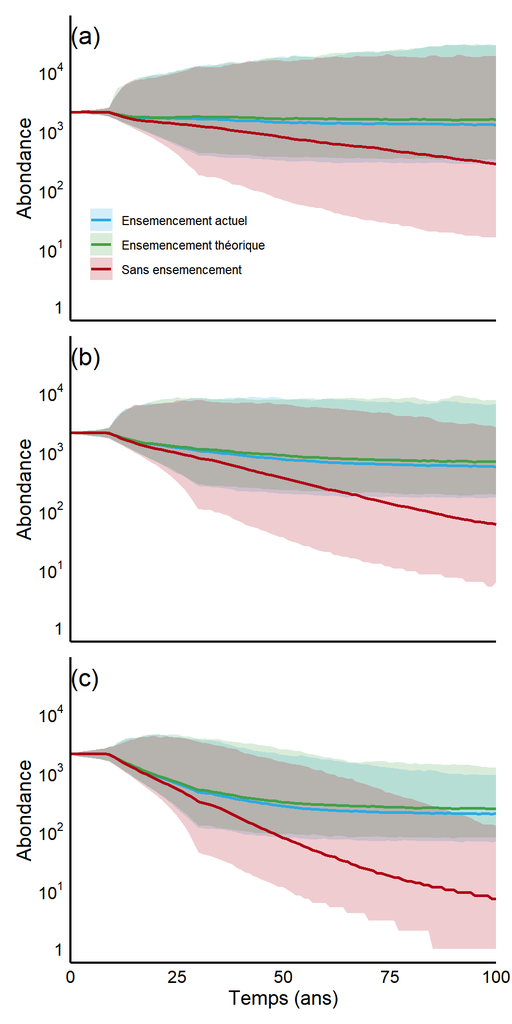

```r
graph_fig2 <- function(d1, d2, d3) {

  # On crée une fonction interne pour éviter de répéter 3 fois le même style
  style_fig2 <- function(data, label, show_x = FALSE, show_legend = FALSE) {
    plot <- ggplot(data, aes(x = Annee, y = Mediane, color = Scenario, fill = Scenario)) +

      # 1. Intervalle de confiance (Ruban)
      geom_ribbon(aes(ymin = Inf_95, ymax = Sup_95), alpha = 0.2, color = NA) +

      # 2. Lignes médianes
      geom_line(linewidth = 1) +

      # 3. Annotation (a),(b) ou (c) en haut à gauche
      annotate("text", x = 0, y = 40000, label = label, size = 6, hjust = 0) +

      # 4. Configuration des axes et thèmes
      scale_y_log10(
        limits = c(1, 50000),
        # Cette fonction affiche "1" pour 10^0, puis 10^1, 10^2...
        labels = function(x) ifelse(x == 1, "1", scales::label_log()(x)),
        # Force les coupures à chaque puissance de 10
        breaks = scales::breaks_log(),
        oob = scales::squish
      ) +
      scale_x_continuous(expand = c(0, 0)) +
      scale_color_manual(values = c("Sans ensemencement" = "#b00014",
                                   "Ensemencement actuel" = "#29abe2",
                                   "Ensemencement théorique" = "#43a047")) +
      scale_fill_manual(values = c("Sans ensemencement" = "#b00014",
                                  "Ensemencement actuel" = "#29abe2",
                                  "Ensemencement théorique" = "#43a047")) +
      theme_minimal() +
      labs(x = if(show_x) "Temps (ans)" else NULL, y = "Abondance", color = NULL, fill = NULL) + # Condition d’afficher le titre de l'axe des x seulement pour le graphique c)
      theme(
        axis.title = element_text(size = 14),
        axis.text.y = element_text(size = 12, color = "black"),
        axis.text.x = if(show_x) element_text(size = 12, color = "black") else element_blank(),# Condition d’afficher le titre de l'axe des x seulement pour le graphique c)
        axis.line = element_line(linewidth = 0.8),
        legend.position = if(show_legend) c(0.25, 0.25) else "none", # Condition d’afficher la légende seulement pour le graphique a)
        legend.background = element_blank(),
        panel.grid = element_blank()
      )
    return(plot)
  }

  # Construction des trois panneaux
  graph_a <- style_fig2(d1, "(a)", show_legend = TRUE)
  graph_b <- style_fig2(d2, "(b)")
  graph_c <- style_fig2(d3, "(c)", show_x = TRUE)

  # Assemblage avec patchwork
  return(graph_a / graph_b / graph_c)
}

# Pour l'afficher :
graphique_fig2 <- graph_fig2(df_nul, df_end, df_mea)
print(graphique_fig2)
```

```r
#ggsave("images/fig2.png",graphique_fig2, width = 5.5, height = 10)
```

### Figure 3

Fonction pour illustrer la figure 3

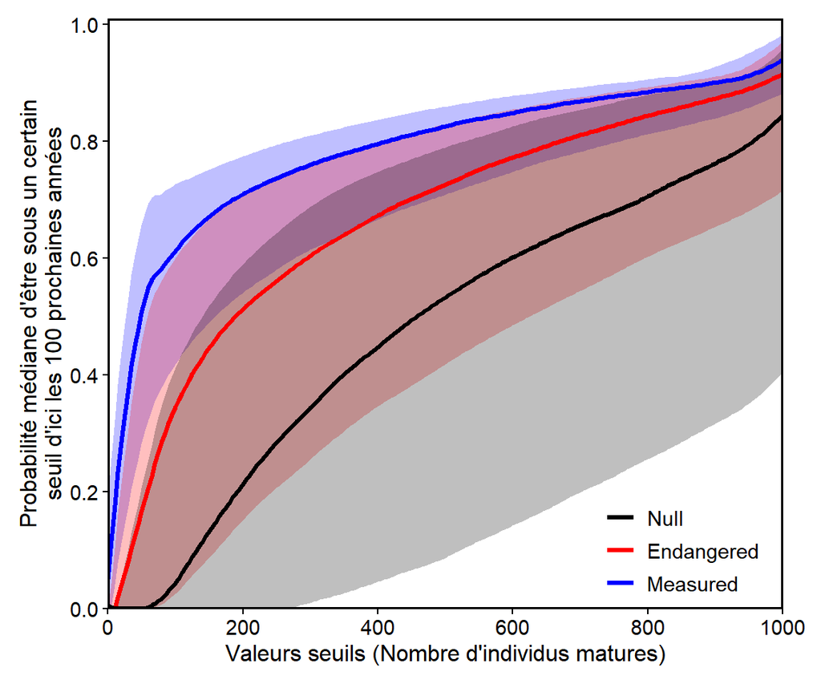

```r
graphique_fig3 <- ggplot(df_smoothed, aes(x = Threshold, group = Scenario)) +

  # 1. Ajout de l'intervalle de confiance (Ruban d'incertitude à 70%)
  geom_ribbon(aes(ymin = Inf_70, ymax = Sup_70, fill = Scenario),
              alpha = 0.25, show.legend = FALSE) +
  # 2. Ajout de la ligne médiane pour chaque scénario
  geom_line(aes(y = Median, color = Scenario), linewidth = 1.1) +

  # 3. Ajout des couleurs voulues
  scale_color_manual(
    values = c("Null" = "black", "Endangered" = "red", "Measured" = "blue"),
    breaks = c("Null", "Endangered", "Measured")
  ) +
  #idem pour les intervalles
  scale_fill_manual(
    values = c("Null" = "black", "Endangered" = "red", "Measured" = "blue"),
    guide  = "none"
  ) +

  # 5. Configuration de l'axe Y (Probabilités de 0 à 1)
  scale_y_continuous(
    limits = c(0, 1.01),
    breaks = seq(0, 1, 0.2),
    expand = c(0, 0), # Supprime l'espace vide entre l'axe et les données
    labels = function(x) sprintf("%.1f", x) # Force l'affichage d'une décimale (ex: 1.0 au lieu de 1)
  ) +

  # 6. Configuration de l'axe X (Seuils d'individus)
  scale_x_continuous(
    limits = c(0, 1000),
    breaks = seq(0, 1000, 200),
    expand = c(0, 0)
  ) +

  theme_classic() +
  labs(
    x = "Valeurs seuils (Nombre d'individus matures)",
    y = "Probabilité médiane d'être sous un certain\nseuil d'ici les 100 prochaines années"
  ) +

  # Ajustement de paramètres graphiques
  theme(
    # Ajout d'un cadre noir tout autour du graphique
    panel.border      = element_rect(colour = "black", fill = NA, linewidth = 1),
    axis.line         = element_blank(),
    legend.position   = c(0.85, 0.1),
    legend.title      = element_blank(),
    legend.text       = element_text(size = 11),
    legend.key        = element_blank(),
    legend.background = element_blank(),
    axis.text         = element_text(color = "black", size = 11),
    axis.title        = element_text(size = 12),
    plot.margin       = margin(10, 20, 10, 10)
  )

# Afficher la figure 3
print(graphique_fig3)
```

```r
# ggsave("images/figure3.png", plot = graphique_fig3, width = 6, height = 5, dpi = 300)
```

### Figure 4

Fonction pour illustrer la figure 4

```r
stades <- c("Larve", "Alevins", "Age 1", "Age 10")
# Positionnement des labels (étiquettes sur les courbes)
label_data <- data.frame(
  Stocking_Stage = factor(stades, levels = stades),
  Stocking       = c(1e7, 5e5, 3e3, 3e2),
  Abundance_Mature = c(5400, 5400, 5400, 5400),
  label          = c("Larve\nstocking", "Alevins\nstocking", "Age 1\nstocking", "Age 10\nstocking")
)
```

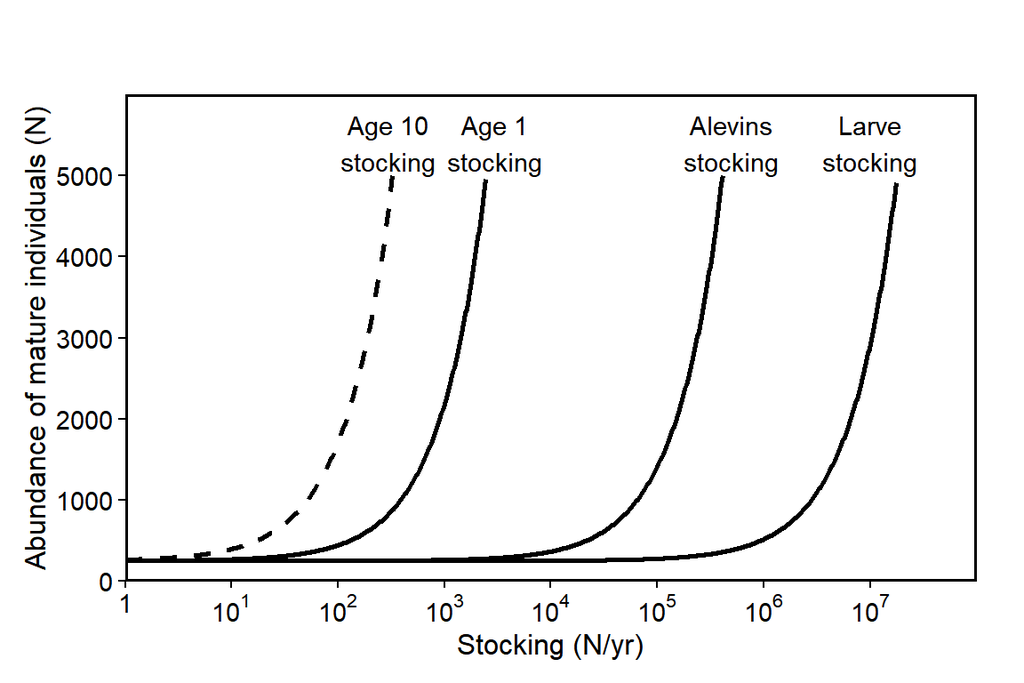

```r
#Créer la figure
graphique_fig4 <- ggplot(df_fig4,
            aes(x        = Stocking,
                y        = Abundance_Mature,
                group    = Stocking_Stage, # Identifie les groupes pour tracer les lignes
                linetype = Stocking_Stage)) +

  # Ajout des lignes de trajectoire
  geom_line(linewidth = 1, color = "black") +

  # Ajout d'étiquettes de texte
  geom_text(data = label_data,
            aes(label  = label),
            size       = 3.8,
            fontface   = "plain",
            color      = "black",
            show.legend = FALSE) +

  # Configuration de l'axe des X en échelle logarithmique
  scale_x_log10(
      limits = c(1, 1e8),
      breaks = 10^(0:7),
      # Cette fonction affiche "1" pour 10^0, puis 10^1, 10^2...
      labels = function(x) ifelse(x == 1, "1", scales::label_log()(x)),
      # expand = c(0,0) force la ligne à toucher l'axe vertical
      expand = c(0, 0)
    ) +

  # Configuration de l'axe des Y (Échelle linéaire)
  scale_y_continuous(
      limits = c(0, 6000),
      breaks = seq(0, 5000, 1000),
      expand = c(0, 0),
    ) +

  # Attribution manuelle des types de lignes (pointillés pour l'âge 10)
  scale_linetype_manual(values = c(
      "Larve"  = "solid",
      "Alevins"    = "solid",
      "Age 1"  = "solid",
      "Age 10" = "dashed"
    )) +

  theme_classic() +
    labs(
      x = "Stocking (N/yr)",
      y = "Abundance of mature individuals (N)"
    ) +
  theme(
      panel.border    = element_rect(colour = "black", fill = NA, linewidth = 1),
      axis.line       = element_blank(),
      legend.position = "none",
      axis.text       = element_text(color = "black", size = 11),
      axis.title      = element_text(size = 12),
      plot.margin     = margin(40, 20, 10, 10)
    )
#ggsave("images/figure4.png", plot = graphique_fig4, width = 6, height = 4.5, dpi = 300)
#Afficher la figure 4 déja construite
print(graphique_fig4)
```

## Interprétations biologiques

L’arrêt des mesures d’ensemencement s’avérerait critique pour la population, exacerbant le risque d’extinction à court terme. Si cette intervention est indispensable à la survie de l’espèce, l’accroissement des quotas au niveau suggéré par Bernatchez (2004) semble toutefois superflu, comme en témoigne la convergence des scénarios dans la Figure 2. Une avenue prometteuse réside plutôt dans l’introduction de spécimens plus âgés (Age 1) : cette stratégie réduit l’effort de repeuplement nécessaire de quatre ordres de grandeur pour atteindre la cible de 1 000 individus matures, comparé à l’ensemencement de larves. Malgré les limites du modèle, cette étude apporte un éclairage essentiel sur la viabilité du Chevalier cuivré (*Moxostoma hubbsi*).

# Partie 2 : Amélioration de l’étude

Combinaisons des matrices initiales en matrices à 3 stades

## Calcul

Cette section ainsi que la suivante servent à permettre de créer les figures présentes dans l’article.

### Agrégation des matrices

##### Matrice de partition (P)

```r
n_orig_corr <- 31
n_super <- 3
P_corr <- matrix(0, nrow = n_super, ncol = n_orig_corr)

P_corr[1, 1] <- 1          # Juvéniles (An 0 condensé)
P_corr[2, 2:10] <- 1       # Préadultes
P_corr[3, 11:31] <- 1      # Adultes

rownames(P_corr) <- c("Juvéniles", "Préadultes", "Adultes")
```

##### Matrice aggréger

```r
agreger_matrice <- function(survie, fecondite, P_corr, label = "Scénario") {

  # 1. Préparation de la survie corrigée
  # (Produit des 3 premiers stades + le reste)
  survie_corr <- c(prod(survie[1:3]), survie[4:length(survie)])

  # 2. Construction de la matrice complète (31x31)
  n_stades <- length(survie_corr) + 1
  mat_full <- matrix(0, nrow = n_stades, ncol = n_stades)
  rownames(mat_full) <- colnames(mat_full) <- c("Juvéniles", paste0("Age", 1:(n_stades-1)))

  # Remplissage fécondité et survie
  mat_full[1, 11:30] <- fecondite
  for(i in 1:length(survie_corr)) {
    mat_full[i+1, i] <- survie_corr[i]
  }

  # 3. Calcul de l'agrégation (K et B)
  ev <- eigen(mat_full)
  w  <- Re(ev$vectors[,1])
  w  <- w / sum(w)

  W <- diag(w)
  # Matrice de pondération K
  K <- W %*% t(P_corr) %*% solve(P_corr %*% W %*% t(P_corr))

  # Matrice agrégée B
  mat_agregee <- P_corr %*% mat_full %*% K
  colnames(mat_agregee) <- rownames(mat_agregee) <- rownames(P_corr)

  # 4. Affichage des résultats
  cat("\n---", label, "---\n")
  cat("Lambda Complet : ", max(Re(eigen(mat_full)$values)), "\n")
  cat("Lambda Agrégé : ", max(Re(eigen(mat_agregee)$values)), "\n")

  return(list(full = mat_full, aggregated = mat_agregee))
}
```

```r
n_orig_corr <- 31
n_super <- 3
P_corr <- matrix(0, nrow = n_super, ncol = n_orig_corr)
P_corr[1, 1] <- 1
P_corr[2, 2:10] <- 1
P_corr[3, 11:31] <- 1
rownames(P_corr) <- c("Juvéniles", "Préadultes", "Adultes")
```

```r
# Calcul pour chaque scénario
res_measured   <- agreger_matrice(survie_m, fecondite_m, P_corr, "Mesuré")
```

```
##
## --- Mesuré ---
## Lambda Complet :  0.9525781
## Lambda Agrégé :  0.9525781
```

```r
res_endangered <- agreger_matrice(survie_e, fecondite_e, P_corr, "Menacé")
```

```
##
## --- Menacé ---
## Lambda Complet :  0.9847611
## Lambda Agrégé :  0.9847611
```

```r
res_null       <- agreger_matrice(survie_n, fecondite_n, P_corr, "Nul")
```

```
##
## --- Nul ---
## Lambda Complet :  1.002742
## Lambda Agrégé :  1.002742
```

```r
measured_3<-res_measured$aggregated
endangered_3<-res_endangered$aggregated
null_pred_3<-res_null$aggregated
```

### Structure initiale

```r
#Structure initiale
calculer_structure_initiale_3 <- function(matrice_3x3, nb_adultes_cible) {
  # 1. Calculer les vecteurs propres
  ev <- eigen(matrice_3x3)

  # 2. Extraire le vecteur associé à la plus grande valeur propre (SSD)
  # On prend la partie réelle et on s'assure que tout est positif
  w <- abs(Re(ev$vectors[, 1]))

  # 3. Calculer le facteur d'échelle pour que le stade 3 (Adultes) soit égal à nb_cible
  # Rapport : cible / valeur actuelle du stade 3 dans le vecteur propre
  facteur <- nb_adultes_cible / w[3]

  # 4. Appliquer le facteur et arrondir
  pop_initiale <- round(w * facteur)

  return(pop_initiale)
}
```

### Fécondités stochastiques

```r
fecondite_stochastique_3 <- function(matrice, n_annees){
  # 1. Identifier le nombre de stades (33)
  n_stades <- nrow(matrice)

  # 2. Extraire la ligne de fécondité théorique (la ligne 1)
  f_theo <- matrice[1, ]

  # 3. Générer les multiplicateurs stochastiques
  # On crée une matrice de multiplicateurs centrés sur 1 (1 + bruit normal)
  multiplicateurs <- matrix(1 + rnorm(n_stades * n_annees, mean = 0, sd = 0.25),
                            nrow = n_stades,
                            ncol = n_annees)

  # 4. Appliquer ces multiplicateurs à nos fécondités théoriques
  taux_fec <- multiplicateurs * f_theo

  return(taux_fec)
}
```

### Survies stochastiques

```r
survie_stochastique_3 <- function(matrice, n_annees) {
  # 1. Extraire la survie réelle (sous-diagonale)
  # Pour une matrice 3x3, p_mesure a une longueur de 2
  p_mesure <- diag(matrice[-1, -ncol(matrice)])
  n_taux <- length(p_mesure)

  # 2. Définit un beta pour chaque transition de survie
  # S1->S2: 5.05 | S2->S3: 0.75
  b_params <- c(5.05, 0.75)

  # Sécurité pour éviter Alpha = Inf si p_mesure vaut 1
  p_mesure <- pmin(p_mesure, 0.9999)

  # 3. Calcul de Alpha
  alpha_params <- (p_mesure * b_params) / (1 - p_mesure)

  # 4. Génération de la matrice de tirages
  # On génère n_annees pour chacun des 3 taux de survie
  taux_survie <- matrix(rbeta(n = n_taux * n_annees,
                              shape1 = alpha_params,
                              shape2 = b_params),
                        nrow = n_taux,
                        ncol = n_annees)

  return(taux_survie)
}
```

### Stases stochastiques

```r
stase_stochastique_3 <- function(matrice, n_annees) {
  p_mesure <- diag(matrice)
  n_stades <- length(p_mesure)

  # On remonte b_params pour plus de stabilité (ex: 80)
  b_params <- c(1, 0.75, 0.75)

  p_mesure_safe <- pmax(pmin(p_mesure, 0.9999), 0)

  # Calcul de alpha (évite division par zéro)
  alpha_params <- (p_mesure_safe * b_params) / pmax(1 - p_mesure_safe, 1e-6)

  # Génération
  taux_stase <- matrix(0, nrow = n_stades, ncol = n_annees)

  # On ne boucle que sur les stades où p > 0
  indices_actifs <- which(p_mesure_safe > 0)

  for(i in indices_actifs) {
    taux_stase[i, ] <- rbeta(n = n_annees,
                             shape1 = alpha_params[i],
                             shape2 = b_params[i])
  }

  return(taux_stase)
}
```

### Figure 2

```r
fig_2_opti_3x3 <- function(matrice_3x3, n_iterations, n_annees, n_ini, Ensemencement, nom_scenario,survie_larve_vers_alevins,survie_alevins_vers_age1) {

  # Calcul du recrutement effectif annuel issu du Ensemencement
  # Ces poissons "apparaissent" directement comme des Age 1 (début du stade Pré-adulte)
  recrutement_larves <- round(Ensemencement[1] * survie_larve_vers_alevins * survie_alevins_vers_age1)
  recrutement_alevins    <- round(Ensemencement[2] * survie_alevins_vers_age1)
  apport_total_recrutement <- recrutement_larves + recrutement_alevins

  # 2. Initialisation
  pop_init <- calculer_structure_initiale_3(matrice_3x3, n_ini)
  resultats_matures <- matrix(0, nrow = n_annees + 1, ncol = n_iterations)

  for (i in 1:n_iterations) {
    # Pré-générer la stochasticité
    fec_stoch   <- fecondite_stochastique_3(matrice_3x3, n_annees)
    surv_stoch  <- survie_stochastique_3(matrice_3x3, n_annees)
    stase_stoch <- stase_stochastique_3(matrice_3x3, n_annees)

    pop <- pop_init
    resultats_matures[1, i] <- pop[3]

    for (t in 1:n_annees) {
      B_t <- matrix(0, nrow = 3, ncol = 3)

      # Construction de la matrice stochastique annuelle
      B_t[1, ] <- fec_stoch[, t]
      diag(B_t) <- diag(B_t) + stase_stoch[, t]
      B_t[2, 1] <- surv_stoch[1, t]
      B_t[3, 2] <- surv_stoch[2, t]

      # 3. Projection de la population naturelle
      pop_next <- B_t %*% pop

      # 4. Ajout de l'ensemencement
      # L'ajout se fait au stade 2 (Préadultes) car ce sont des poissons
      # qui ont survécu à leur première année (ils entrent dans l'année 2).
      pop_next[2] <- pop_next[2] + apport_total_recrutement

      pop <- round(pmax(pop_next, 0))
      resultats_matures[t + 1, i] <- pop[3]
    }
  }

  return(data.frame(
    Annee = 0:n_annees,
    Mediane = apply(resultats_matures, 1, median),
    Inf_95 = apply(resultats_matures, 1, quantile, probs = 0.025),
    Sup_95 = apply(resultats_matures, 1, quantile, probs = 0.975),
    Scenario = nom_scenario
  ))
}

# Calculs
df_null <- bind_rows(
  fig_2_opti_3x3(null_pred_3, 5000, 100, 2000, Ensemencement_nul, "Sans Ensemencement", 0.024, 0.007),
  fig_2_opti_3x3(null_pred_3, 5000, 100, 2000, Ensemencement_present, "Ensemencement actuel", 0.024, 0.007),
  fig_2_opti_3x3(null_pred_3, 5000, 100, 2000, Ensemencement_propose, "Ensemencement théorique", 0.024, 0.007))
df_end <- bind_rows(
  fig_2_opti_3x3(endangered_3, 5000, 100, 2000, Ensemencement_nul, "Sans Ensemencement",0.023, 0.007),
  fig_2_opti_3x3(endangered_3, 5000, 100, 2000, Ensemencement_present, "Ensemencement actuel",0.023, 0.007),
  fig_2_opti_3x3(endangered_3, 5000, 100, 2000, Ensemencement_propose, "Ensemencement théorique",0.023, 0.007))
df_meas <- bind_rows(
  fig_2_opti_3x3(measured_3, 5000, 100, 2000, Ensemencement_nul, "Sans Ensemencement",0.023, 0.006),
  fig_2_opti_3x3(measured_3, 5000, 100, 2000, Ensemencement_present, "Ensemencement actuel",0.023, 0.006),
  fig_2_opti_3x3(measured_3, 5000, 100, 2000, Ensemencement_propose, "Ensemencement théorique",0.023, 0.006))

# Remplace les 0 par 0.1 pour permettre le calcul du log10 sans déformer le graphique
df_null <- df_null %>% mutate(across(c(Mediane, Inf_95, Sup_95), ~if_else(.x < 0.1, 0.0001, .x)))
df_end  <- df_end  %>% mutate(across(c(Mediane, Inf_95, Sup_95), ~if_else(.x < 0.1, 0.0001, .x)))
df_meas <- df_meas %>% mutate(across(c(Mediane, Inf_95, Sup_95), ~if_else(.x < 0.1, 0.0001, .x)))
```

### Figure 3

Fonction servant à faire 5000 itérations pour les 3 matrices avec un niveau d’ensemencement spécifique en calculant le pourcentage de chance que la population soit sous un seuil spécifique après 100 ans.

```r
# Simulation pour la figure 3 : Analyse de viabilité de la population (PVA)
simuler_trajectoires_adultes_3 <- function(matrice, n_iterations, n_annees = 100) {
  n_stades <- nrow(matrice) #4 comme les matrices modifiées
  historique <- matrix(0, nrow = n_iterations, ncol = n_annees + 1) # matrice pour stocker les résultats


  # Boucle d'itérations
  for (i in 1:n_iterations) {

    # Génération de la stochasticité environnementale pour toute la durée de la simulation
    mat_fec  <- fecondite_stochastique_3(matrice, n_annees)
    mat_surv <- survie_stochastique_3(matrice, n_annees)
    mat_stas <- stase_stochastique_3(matrice,n_annees)

    # Initialisation de la population à t = 0 (1000 individus répartis selon la structure stable)
    pop <- calculer_structure_initiale_3(matrice, 1000)

    # Ensemencement du nombre de matures (Stade 3) au temps initial
    historique[i, 1] <- pop[3]

    # Boucle annuelle
    for (t in 1:n_annees) {
      M_t <- matrix(0, nrow = n_stades, ncol = n_stades)

      # Construction de la matrice de transition annuelle (Lefkovitch)
      # Survie et transition : remplit la diagonale inférieure (passage d'un stade à l'autre)
      diag(M_t[-1, -n_stades]) <- mat_surv[1:(n_stades - 1), t]

      # Stase : probabilité de rester dans le même stade (Pré-adulte et Adulte)
      M_t[2,2] <- mat_stas[2,t]
      M_t[3,3] <- mat_stas[3,t]

      # Fécondité : les adultes (Stade 3) produisent des recrues (Stade 1)
      M_t[1,3] <- mat_fec[3,t]

      # Projection de la population : multiplication matricielle
      pop <- M_t %*% pop

      # Ensemencement du nombre d'adultes matures (stade 3)
      historique[i, t + 1] <- pop[3]
    }
  }

  # Retourne une matrice où chaque ligne est une simulation complète de 100 ans
  return(historique)
}

# Calcul des statistiques pour les intervales de confiance à 70%
# Transforme les trajectoires temporelles en probabilités de passer sous des seuils critiques.
calculer_stats <- function(historique, nom_scenario) {
  # Définition des seuils d'abondance à tester (de 0 à 1000 individus)
  seuils <- seq(0, 1000, by = 1)
  n_sims <- nrow(historique)

  # Matrice pour stocker la proportion de temps passé sous chaque seuil
  temps_sous_seuil <- matrix(0, nrow = n_sims, ncol = length(seuils))
  for (j in seq_along(seuils)) {
    # Pour chaque simulation, on calcule la fréquence (%) d'années passées sous le seuil j
    temps_sous_seuil[, j] <- rowMeans(historique < seuils[j])
  }

  # Compilation des résultats statistiques par seuil
  data.frame(
    Threshold = seuils,
    # Médiane des probabilités sur l'ensemble des itérations
    Median    = apply(temps_sous_seuil, 2, median),
    # Intervalle de confiance à 70% (centile 15 et 85)
    Inf_70    = apply(temps_sous_seuil, 2, quantile, probs = 0.15),
    Sup_70    = apply(temps_sous_seuil, 2, quantile, probs = 0.85),
    Scenario  = factor(nom_scenario, levels = c("Null", "Endangered", "Measured"))
  )
}
```

```r
# Lancement des simulations de 5000 itérations pour les 3 scénarios
hist_null <- simuler_trajectoires_adultes_3(null_pred_3,  5000)
hist_end  <- simuler_trajectoires_adultes_3(endangered_3, 5000)
hist_meas <- simuler_trajectoires_adultes_3(measured_3,   5000)

# Stocker les résultats dans un data frame unique
df_final <- bind_rows(
  calculer_stats(hist_null, "Null"),
  calculer_stats(hist_end,  "Endangered"),
  calculer_stats(hist_meas, "Measured")
)

# Lissage des résultats
df_final$Scenario <- factor(df_final$Scenario, levels = c("Measured", "Endangered", "Null"))

df_smoothed <- df_final %>%
  group_by(Scenario) %>%
  mutate(
    # Application d'une régression loess sur la médiane et les intervalles
    Median = predict(loess(Median ~ Threshold, span = 0.15)),
    Inf_70 = predict(loess(Inf_70 ~ Threshold, span = 0.15)),
    Sup_70 = predict(loess(Sup_70 ~ Threshold, span = 0.15)),

    # Empêche les valeurs négatives dues au lissage
    Median = pmax(Median, 0),
    Inf_70 = pmax(Inf_70, 0),
    Sup_70 = pmax(Sup_70, 0)
  ) %>%
  ungroup()
```

### Figure 4

```r
fig_4_3x3 <- function(matrice_3x3, Ensemencement_base, s_larve_alevins, s_alevins_age1, n_iterations = 100) {

  # 1. Paramètres de survie pour l'ensemencement
  # On calcule combien d'individus atteignent le Stade 2 (Age 1)
  s_larve_to_age1 <- s_larve_alevins * s_alevins_age1
  s_alevins_to_age1   <- s_alevins_age1

  # 2. Sous-fonction de simulation déterministe
  simulate_point_3x3 <- function(stocking_val, stage_to_stock) {

    # Initialisation de la population (structure stable pour 1000 adultes)
    # On utilise votre fonction spécifique pour le 3x3
    pop <- calculer_structure_initiale_3(matrice_3x3, 1000)

    for (t in 1:n_iterations) {
      # Projection matricielle : pop(t+1) = M * pop(t)
      pop <- as.vector(matrice_3x3 %*% pop)

      # A. Application de l'ensemencement de BASE (actuel)
      # On ajoute les larves et alevins convertis en Age 1 au Stade 2
      apport_base <- (Ensemencement_base[1] * s_larve_to_age1) + (Ensemencement_base[2] * s_alevins_to_age1)
      pop[2] <- pop[2] + apport_base

      # B. Application de l'effort d'ensemencement SUPPLÉMENTAIRE (Scénarios)
      if (stage_to_stock == "Larve") {
        pop[2] <- pop[2] + (stocking_val * s_larve_to_age1)
      } else if (stage_to_stock == "Alevins") {
        pop[2] <- pop[2] + (stocking_val * s_alevins_to_age1)
      } else if (stage_to_stock == "Age 1") {
        # Ajout direct au Stade 2
        pop[2] <- pop[2] + stocking_val
      } else if (stage_to_stock == "Age 10") {
        # Dans un modèle 3x3, l'Age 10 est simplement un "Adulte" (Stade 3)
        pop[3] <- pop[3] + stocking_val
      }

      # Sécurité pour éviter les nombres négatifs
      pop <- pmax(pop, 0)
    }

    # Retourne l'abondance du stade 3 (Adultes)
    return(pop[3])
  }

  # 3. Création de la grille d'efforts (Log scale)
  efforts  <- seq(0, 9, length.out = 500) # 500 points pour la fluidité
  grid_vals <- c(0, 10^efforts)
  stades   <- c("Larve", "Alevins", "Age 1", "Age 10")

  # 4. Calcul des données
  df_clean <- expand.grid(Stocking = grid_vals, Stocking_Stage = stades) %>%
    mutate(
      Stocking_Stage = factor(Stocking_Stage, levels = stades),
      Abundance_Mature = mapply(simulate_point_3x3, Stocking, as.character(Stocking_Stage))
    ) %>%
    filter(Stocking > 0,
           !is.na(Abundance_Mature),
           Abundance_Mature <= 5000) # Limite identique à votre fig 4 originale

  return(df_clean)
}

df_fig4_3x3 <- fig_4_3x3(
  matrice_3x3 = measured_3,
  Ensemencement_base = Ensemencement_present,
  s_larve_alevins = 0.023,
  s_alevins_age1 = 0.006
)
```

```r
stades <- c("Larve", "Alevins", "Age 1", "Age 10")

# Positionnement des labels (étiquettes sur les courbes)

label_data <- data.frame(
  Stocking_Stage = factor(stades, levels = stades),
  Stocking       = c(1e7, 5e5, 3e3, 3e2),
  Abundance_Mature = c(5400, 5400, 5400, 5400),
  label          = c("Larves\nstockées", "Alevins\nstockés", "Age 1\nstockés", "Age 10\nstockés"))
```

## Résultats

### Figure 2

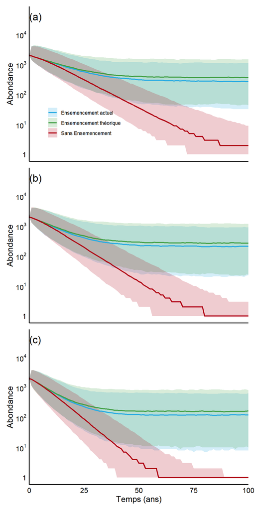

```r
graph_fig2 <- function(d1, d2, d3) {

  # On crée une fonction interne pour éviter de répéter 3 fois le même style
  style_fig2 <- function(data, label, show_x = FALSE, show_legend = FALSE) {
    plot <- ggplot(data, aes(x = Annee, y = Mediane, color = Scenario, fill = Scenario)) +

      # 1. Intervalle de confiance (Ruban)
      geom_ribbon(aes(ymin = Inf_95, ymax = Sup_95), alpha = 0.2, color = NA) +

      # 2. Lignes médianes
      geom_line(linewidth = 1) +

      # 3. Annotation (a),(b) ou (c) en haut à gauche
      annotate("text", x = 0, y = 40000, label = label, size = 6, hjust = 0) +

      # 4. Configuration des axes et thèmes
      scale_y_log10(
        limits = c(1, 50000),
        # Cette fonction affiche "1" pour 10^0, puis 10^1, 10^2...
        labels = function(x) ifelse(x == 1, "1", scales::label_log()(x)),
        # Force les coupures à chaque puissance de 10
        breaks = scales::breaks_log(),
        oob = scales::squish
      ) +
      scale_x_continuous(expand = c(0, 0)) +
      scale_color_manual(values = c("Sans Ensemencement" = "#b00014",
                                    "Ensemencement actuel" = "#29abe2",
                                    "Ensemencement théorique" = "#43a047")) +
      scale_fill_manual(values = c("Sans Ensemencement" = "#b00014",
                                   "Ensemencement actuel" = "#29abe2",
                                   "Ensemencement théorique" = "#43a047")) +
      theme_minimal() +
      labs(x = if(show_x) "Temps (ans)" else NULL, y = "Abondance", color = NULL, fill = NULL) + # Condition d’afficher le titre de l'axe des x seulement pour le graphique c)
      theme(
        axis.title = element_text(size = 14),
        axis.text.y = element_text(size = 12, color = "black"),
        axis.text.x = if(show_x) element_text(size = 12, color = "black") else element_blank(),# Condition d’afficher le titre de l'axe des x seulement pour le graphique c)
        axis.line = element_line(linewidth = 0.8),
        legend.position = if(show_legend) c(0.25, 0.25) else "none", # Condition d’afficher la légende seulement pour le graphique a)
        legend.background = element_blank(),
        panel.grid = element_blank()
      )
    return(plot)
  }

  # Construction des trois panneaux
  graph_a <- style_fig2(d1, "(a)", show_legend = TRUE)
  graph_b <- style_fig2(d2, "(b)")
  graph_c <- style_fig2(d3, "(c)", show_x = TRUE)

  # Assemblage avec patchwork
  return(graph_a / graph_b / graph_c)
}

# Pour l'afficher :
graphique_fig2_3 <- graph_fig2(df_null, df_end, df_meas)
print(graphique_fig2_3)
```

```r
#ggsave("images/fig_2_3.png",graphique_fig2_3)
```

### Figure 3

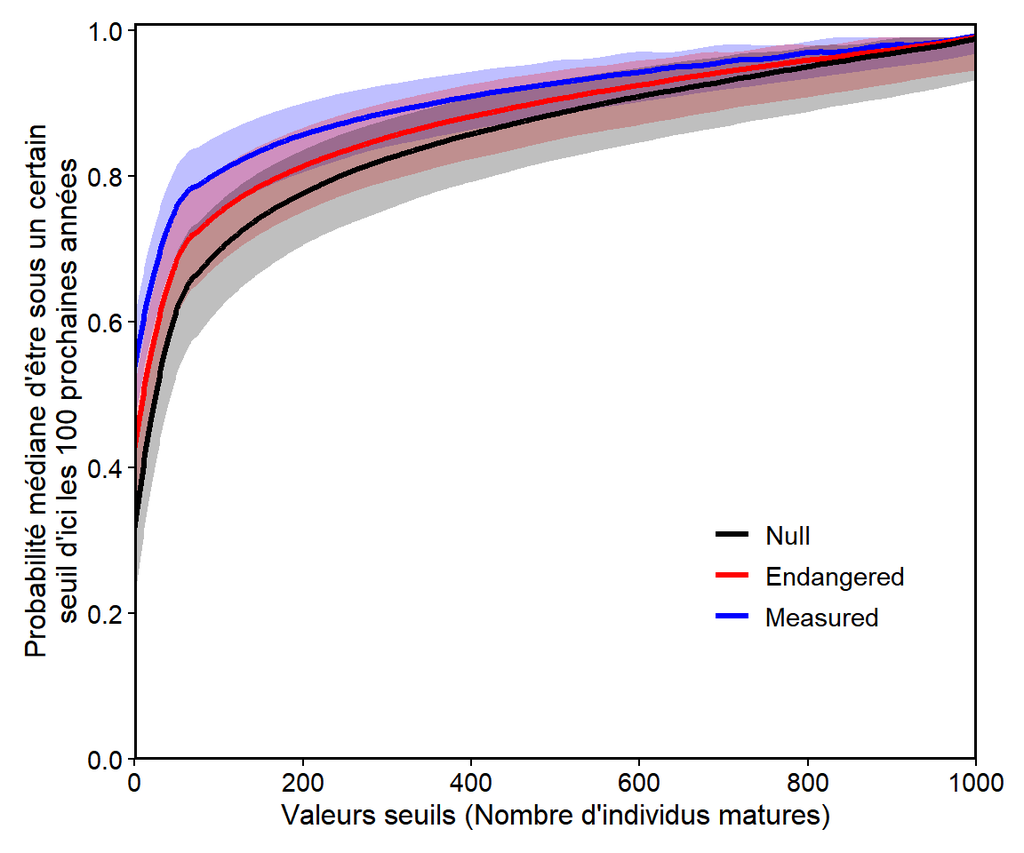

```r
# Création du Graphique Final
fig3_3 <- ggplot(df_smoothed, aes(x = Threshold, group = Scenario)) +
  # Ajout des enveloppes d'incertitude (Rubans de confiance à 70%)
  geom_ribbon(aes(ymin = Inf_70, ymax = Sup_70, fill = Scenario),
              alpha = 0.25, show.legend = FALSE) +
  # Ajout des lignes de tendance médianes
  geom_line(aes(y = Median, color = Scenario), linewidth = 1.1) +

  # Ajout des couleurs voulues
  scale_color_manual(
    values = c("Null" = "black", "Endangered" = "red", "Measured" = "blue"),
    breaks = c("Null", "Endangered", "Measured")
  ) +
  # Idem pour les intervalles
  scale_fill_manual(
    values = c("Null" = "black", "Endangered" = "red", "Measured" = "blue"),
    guide  = "none"
  ) +
  # Mise en forme des axes : probabilité de 0 à 1 (y) et individus de 0 à 1000 (x)
  scale_y_continuous(
    limits = c(0, 1.01),
    breaks = seq(0, 1, 0.2),
    expand = c(0, 0),
    labels = function(x) sprintf("%.1f", x)
  ) +
  scale_x_continuous(
    limits = c(0, 1000),
    breaks = seq(0, 1000, 200),
    expand = c(0, 0)
  ) +

  theme_classic() +
  labs(
    x = "Valeurs seuils (Nombre d'individus matures)",
    y = "Probabilité médiane d'être sous un certain\nseuil d'ici les 100 prochaines années"
  ) +

  theme(
    panel.border      = element_rect(colour = "black", fill = NA, linewidth = 1),
    axis.line         = element_blank(),
    legend.position   = c(0.80, 0.25),
    legend.title      = element_blank(),
    legend.text       = element_text(size = 11),
    legend.key        = element_blank(),
    legend.background = element_rect(fill = "white", color = NA),
    axis.text         = element_text(color = "black", size = 11),
    axis.title        = element_text(size = 12),
    plot.margin       = margin(10, 20, 10, 10)
  )

# Afficher la figure 3
print(fig3_3)
```

```r
#ggsave("images/figure3_3.png", plot = fig3_3, width = 6, height = 5, dpi = 300)
```

### Figure 4

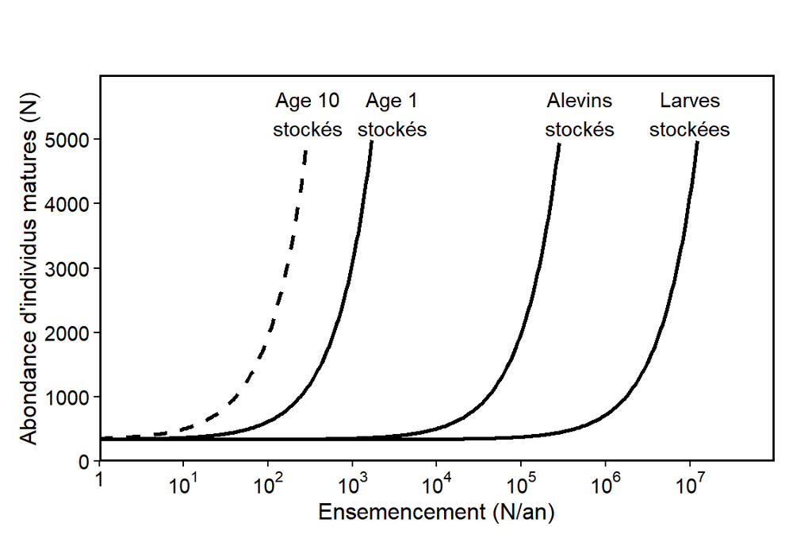

```r
#Créer la figure
graphique_fig4_3 <- ggplot(df_fig4_3x3,
            aes(x        = Stocking,
                y        = Abundance_Mature,
                group    = Stocking_Stage, # Identifie les groupes pour tracer les lignes
                linetype = Stocking_Stage)) +

  # Ajout des lignes de trajectoire
  geom_line(linewidth = 1, color = "black") +

  # Ajout d'étiquettes de texte
  geom_text(data = label_data,
            aes(label  = label),
            size       = 3.8,
            fontface   = "plain",
            color      = "black",
            show.legend = FALSE) +

  # Configuration de l'axe des X en échelle logarithmique
  scale_x_log10(
      limits = c(1, 1e8),
      breaks = 10^(0:7),
      # Cette fonction affiche "1" pour 10^0, puis 10^1, 10^2...
      labels = function(x) ifelse(x == 1, "1", scales::label_log()(x)),
      # expand = c(0,0) force la ligne à toucher l'axe vertical
      expand = c(0, 0)
    ) +

  # Configuration de l'axe des Y (Échelle linéaire)
  scale_y_continuous(
      limits = c(0, 6000),
      breaks = seq(0, 5000, 1000),
      expand = c(0, 0),
    ) +

  # Attribution manuelle des types de lignes (pointillés pour l'âge 10)
  scale_linetype_manual(values = c(
      "Larve"  = "solid",
      "Alevins"    = "solid",
      "Age 1"  = "solid",
      "Age 10" = "dashed"
    )) +

  theme_classic() +
    labs(
      x = "Ensemencement (N/an)",
      y = "Abondance d'individus matures (N)"
    ) +
  theme(
      panel.border    = element_rect(colour = "black", fill = NA, linewidth = 1),
      axis.line       = element_blank(),
      legend.position = "none",
      axis.text       = element_text(color = "black", size = 11),
      axis.title      = element_text(size = 12),
      plot.margin     = margin(40, 20, 10, 10)
    )
# ggsave("images/figure4_3.png", plot = graphique_fig4_3, width = 6, height = 4.5, dpi = 300)
#Afficher la figure 4 déja construite
print(graphique_fig4_3)
```

## Déclaration de l’utilisation de l’IAg

Cette section du code informatique a été annotée par Gemini 3, puis adaptée à partir des requêtes :

« J’aimerais ajouter un reEnsemencement (Ensemencement_present) à chaque année dans ma boucle »

« J’aimerais ajouter des taux de survie et fecondite variables à ce modèle suivant taux_survie et taux_fecondite »

« Est-ce que le résultat du prompt précédent permet d’avoir une matrice de 100 tirages du code suivant? »

« Mon modèle ne prends pas en compte le fait que les 3 premiers stades sont dans la même annnée, j’aurais donc besoin de faire un calcul de survie combinée, mais j’aimerais conserver le moyen de savoir le nombre d’individus par stade quand même »

« J’aimerais donc ajouter la stochasticité à mon modèle simule, en extrayant les valeurs des matrices obtenues par ma fonction »

« Génial, j’aimerais maintenant ajouter à ce modèle la survie stochastique et la fecondite stochastique, calculée selon ce modèle »

« Comment faire en sorte que l’axe des y soit toujours entre 10000 et 0 peut-importe mes résultats? »

« J’aimerais ajouté une option pour ajouter un reEnsemencement des stades 2 et 3 (alevins et larve) à cette fonction »

« J’ai fait quelques corrections à la fonction cependant le résultat est encore trop bas pour ce qui est escompté (on s’attendrait qu’il passe de 2000 matures à un peu moins de 1000 »

« Génial ça fonctionne ! J’aimerais maintenant que la boucle ajoute mes trois situations de Ensemencement au graphique »

« Why is there no CI on my graph »

« J’ignore pourquoi, mais mon script donne le résultat attendu pour l’ensemble des simulations sauf meas_nul…. »

« Comment écrirait tu ceci en format latex? Stochastic models were also used to calculate the probability of extinction of copper redhorse across the different scenarios… »

« J’aimerais refaire ce modèle, mais qu’il prenne en compte les stades 1-3, en considérant quand même que ces 3 stades occurent au sein de la même année. Piste possible est ce que le modèle pourrait être fait en jour? »

« Pourquoi le résultat obtenu (image 1) ne donne pas le résultat escompté (image 2) au niveau du rouge (absence d’ensemencement) »

« Présentement j’arrive à ceci, mais il y a un problème probable dans l’intégration du Ensemencement et de la structure initiale de la population »

« Je m’attendrais à ce que le résultat ressemble à la ligne rouge, pourquoi au début n’y a t-il pas de moment stable suivi d’un léger dip? »

« Est-ce qu’il y a moyen d’optimiser ce code? »

« Est-ce qu’il y aurait moyen de faire fonctionner ceci comme ça je n,ai pas besoin de les garder dans mon environnement? »

« Peux-tu uniformiser la section calcul figure 4? »

« Est-ce que tu sais pourquoi mon graphique (image 1) n’est pas exactement comme l’image que je veux reproduire (image 2). Je veux que les courbes suivent les mêmes trajectoires »

« Peux tu ajouter des commentaires dans ce code? »

« J’aimerais que tu m’indique des articles qui parlent de comment combiner l’effet de la stochasticité de plusieurs stades lorsqu’ils sont combinés en un seul »

« Peux tu me résumé la section 2 de ce texte : https://www.biorxiv.org/content/10.64898/2026.02.04.703802v1.full.pdf »

« Donc si j’ai cette matrice et que je veux regrouper les stades juvéniles en un seul (1:3) les stades préadultes (4:12) et les stades adultes (13:33), à quoi ressemblerait ma matrice P? »

« Je suis donc parvenu a agréé mes matrices, mais je ne sais pas comment combiné les taux stochastiques. Peux-tu me référer à des articles qui en parle? »

« Si j’avais 10 stades qui variaient selon cette formule et qu’ils sont désormais agrégé en un seul stade, quelle formule devrais-je utilisé pour faire varié la fécondité totale »

« Comment adapter la stochasticité de la survie selon les modifications faites dernièrement? »

« Théoriquement en combinant mes valeurs, est-ce que la variation sera plus haute (beta<5.05) ou plus faible (beta>5.05) ou égale? »

« J’aimerais adapter cette fonction pour qu’elle puisse utilisé mes matrices 3x3 »

« Peux tu adapter fig_2_opti_3x3 pour qu’elle utilise struct_3x3_stable? »

« Ok mais présentement la fonction ne fait pas l’ensemencement à chaque année et j’aimerais qu’elle ne soit pas jumelé en un seul stade lors de son ajout… Je proposerais d’utiliser un facteur comme par exemple dire que Ensemencement[2] (alevins) = 15000x0.006 avant de l’ajouté aux Préadultes et que Ensemencement[1] (larves) = 250000x0.023x0.006 »

« Y a t’il moyen de diminuer la taille des matrices dans le html »

« Suivant notre code établit précedemment, j’aimerais faire une figure qui représente : Probability of copper redhorse to be below a total population threshold within the next 100 yr based on our stochastic population dynamics scenarios. Lines: median of 5000 iterations; colored envelopes: 70% CIs »

« Mon collègue utilise ceci et arrive à ce résultat, y-a-t’il moyen de l’améliorer (est-ce qu’il y a des fautes par exemple dans l’ensemencement ou autre) »

« J’aimerais reproduire la figure 4 en utilisant la même matrice (3x3) que j’ai utilisé pour faire la figure 2_3 »

« J’aimerais essayé d’arriver à un résultat plus semblable à celui de l’étude (fig 3) (image 2). J’utilise exactement les mêmes données que l’étude donc pourquoi mon résultat (image 1) n’est pas le même »

« Peux tu uniformiser mon code et éviter qu’il fasse des calculs en double »

« Est-ce qu’il y a moyen que je change mon kable pour qu’il soit pas toute la largeur de la page? »

Google (2026). Gemini 3 (**version du 23 avril**) [grand modèle de langage]

## Bibliographie

Bannester-Marchand, N., Vachon, N., Mandrak, N. et Blanchet, F. (2025). Population viability analysis of the endangered copper redhorse *Moxostoma hubbsi*. *Endangered Species Research*, *57*, 21‑31. https://doi.org/10.3354/esr01395

Bernatchez, L. (2004). *Considérations génétiques et protocole de reproduction relatifs au plan de rétablissement du chevalier cuivré (*Moxostoma hubbsi*)* ( [Technique]). Ministère des Ressources naturelles, de la Faune et des Parcs, direction de l’aménagement de la faune de Montréal, de Laval et de la Montérégie, Longueuil et Pêches et Océans Canada. https://numerique.banq.qc.ca/patrimoine/details/52327/66775

Dahlberg, M. D. (1979). A review of survival rates of fish eggs and larvae in relation to impact assessments. *Marine Fisheries Review*, *41*(3).